### Labs 7.8.2: Splines and 7.8.3: GAMs

## Objectives

1. Develop regression and smoothing splines to optimize model fit.
2. Interpret plots of spline fits.
3. Develop and explore Generalized Additive Models (GAMs) to study multiple features simultaneously.

Before we first fit Wage to Age using a regression spline, we create an age grid of all occurrences of ages in the dataset - 18 to 80.

```r
library(splines)
require(ISLR)
```

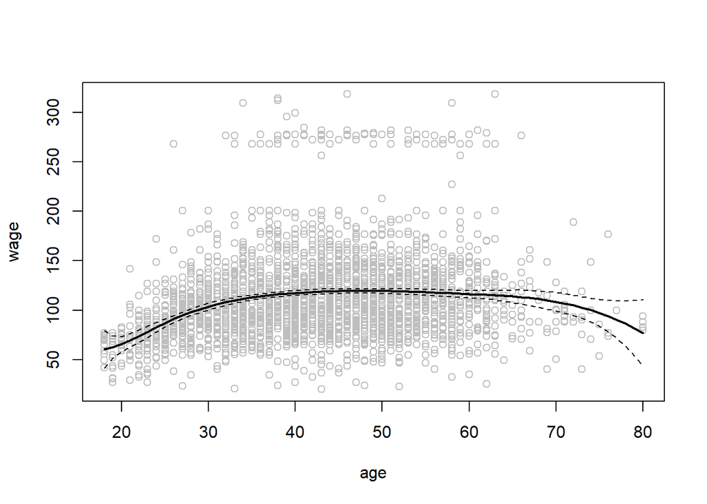

```r
attach(Wage)

agelims=range(age)
age.grid=seq(from=agelims[1],to=agelims[2])

fit = lm(wage~bs(age,knots=c(25,40,60)),data=Wage)
pred=predict(fit,newdata=list(age=age.grid),se=T)
plot(age,wage,col="gray")
lines(age.grid,pred$fit,lwd=2)
lines(age.grid,pred$fit+2*pred$se,lty="dashed")
lines(age.grid,pred$fit-2*pred$se,lty="dashed")
```

Here we produced a spline with 3 knots - 6 degrees of freedom (or basis functions). We can also use `df`:

```r
dim(bs(age,knots=c(25,40,60)))
```

```
## [1] 3000    6
```

```r
dim(bs(age,df=6))
```

```
## [1] 3000    6
```

```r
attr(bs(age,df=6),"knots")
```

```
##   25%   50%   75%
## 33.75 42.00 51.00
```

Here, R chooses the 3 knots.

Now, in order to fit a natural spline, use ns():

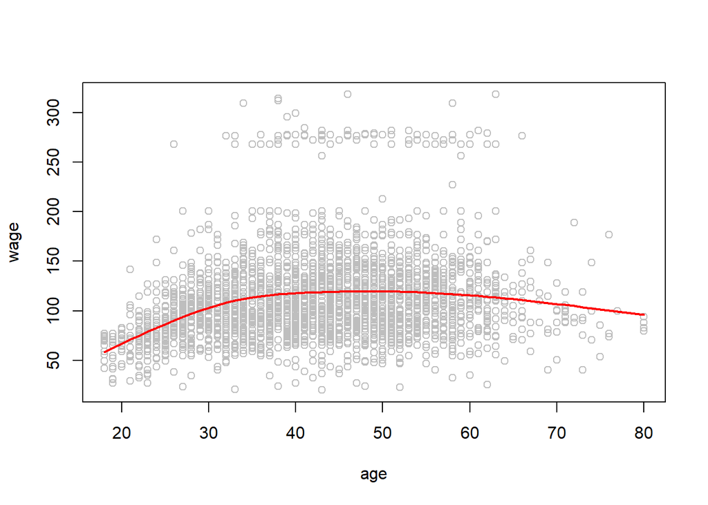

```r
fit2=lm(wage~ns(age,df=4),data=Wage)
pred2=predict(fit2,newdata=list(age=age.grid),se=T)
plot(age,wage,col="gray")
lines(age.grid,pred2$fit,col="red",lwd=2)
```

In order to fit a smoothing spline, we use smooth.spline()

In the following piece of code, what differences do you expect in the plots of fit and fit2?

```r
plot(age,wage,xlim=agelims,cex=.5,col="darkgrey")
title("Smoothing Spline")
fit=smooth.spline(age,wage,df=16)
fit2=smooth.spline(age,wage,cv=TRUE)
fit2$df
```

```
## [1] 6.794596
```

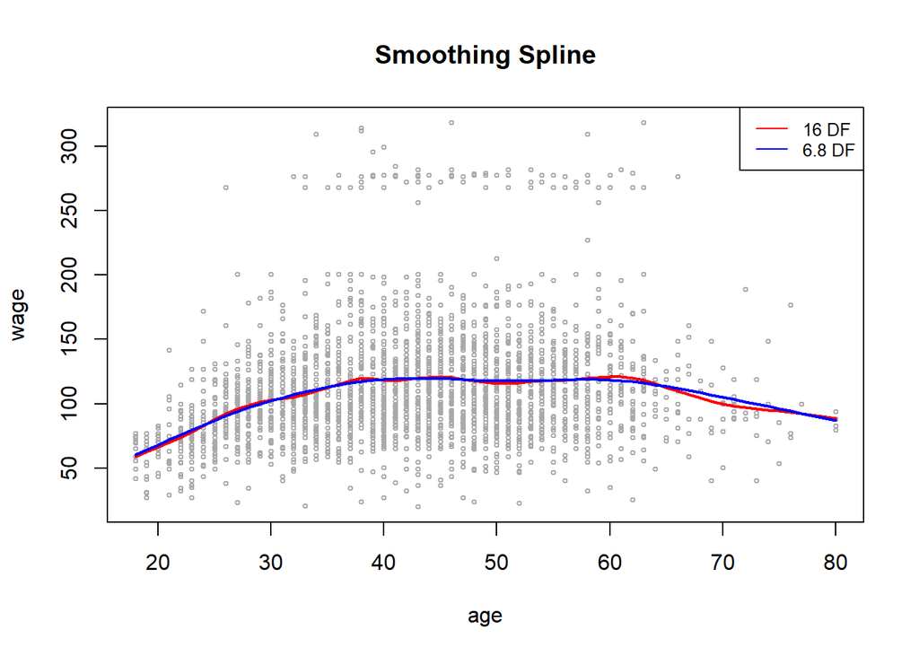

```r
lines(fit,col="red",lwd=2)
lines(fit2,col="blue",lwd=2)
legend("topright",legend=c("16 DF","6.8 DF"),
       col=c("red","blue"),lty=1,lwd=,cex=.8)
```

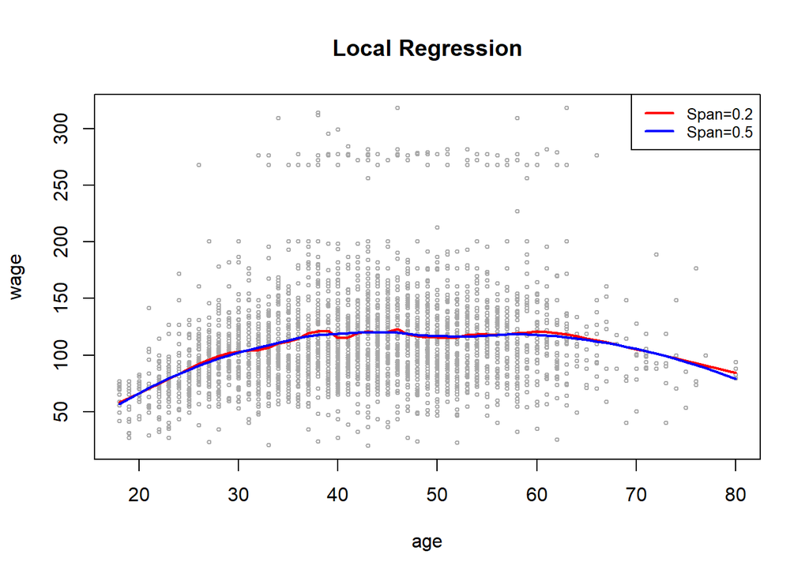

```r
plot(age,wage,xlim=agelims,cex=.5,col="darkgrey")
title("Local Regression")
fit=loess(wage~age,span=.2,data=Wage)
fit2=loess(wage~age,span=.5,data=Wage)
lines(age.grid,predict(fit,data.frame(age=age.grid)),
      col="red",lwd=2)
lines(age.grid,predict(fit2,data.frame(age=age.grid)),
      col="blue",lwd=2)
legend("topright",legend=c("Span=0.2","Span=0.5"),
       col=c("red","blue"),lty=1,lwd=2,cex=.8)
```

Here we have performed local linear regression using spans of 0.2 and 0.5: that is, each neighborhood consists of 20% or 50% of the observations.

We now fit a GAM to predict wage using natural spline functions of year and age. Education as a qualitative predictor.

This is basically a linear regression model using different basis functions, so lm() is appropriate.

```r
gam1=lm(wage~ns(year,4)+ns(age,5)+education,data=Wage)
```

How about if we want to use more general GAM components? Like smoothing splines?

```r
library(gam)
gam.m3=gam(wage~s(year,4)+s(age,5)+education,data=Wage)
```

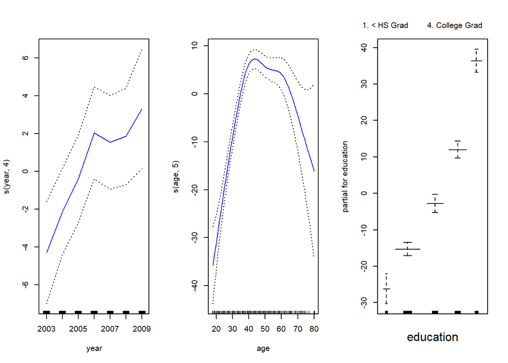

```r
par(mfrow=c(1,3))
plot(gam.m3,se=TRUE,col="blue")
```

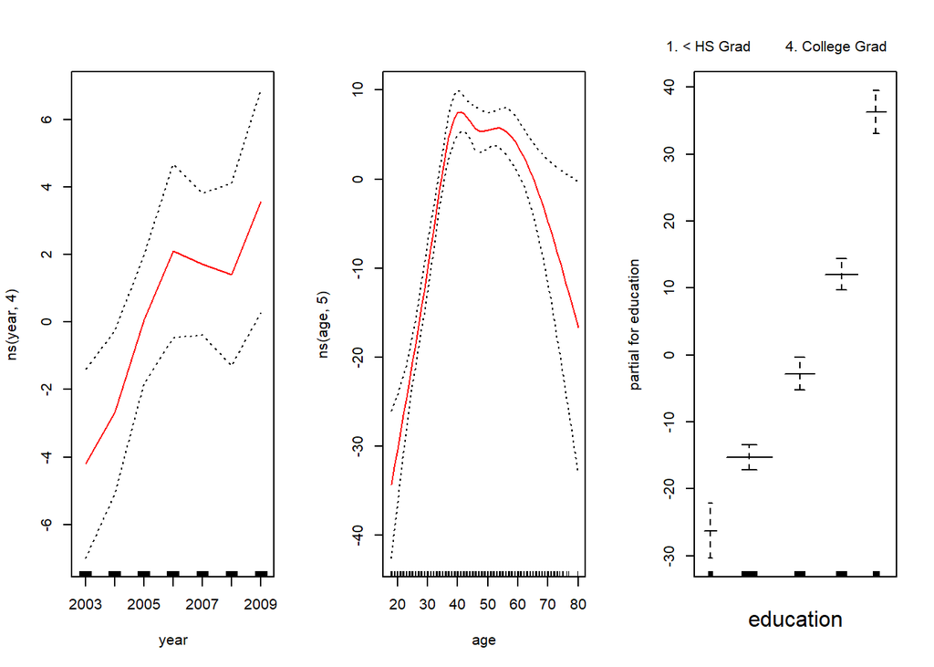

```r
plot.Gam(gam1,se=T,col="red")
```

All the terms are fit simultaneously, taking each other into account for the response.

In these plots, `year` looks linear. Perform ANOVA to study which model is the best fit: no year, linear year, or spline year.

```r
gam.m1=gam(wage~s(age,5)+education,data=Wage)
gam.m2=gam(wage~year+s(age,5)+education,data=Wage)
anova(gam.m1,gam.m2,gam.m3,test="F")
```

```
## Analysis of Deviance Table
##
## Model 1: wage ~ s(age, 5) + education
## Model 2: wage ~ year + s(age, 5) + education
## Model 3: wage ~ s(year, 4) + s(age, 5) + education
##   Resid. Df Resid. Dev Df Deviance       F    Pr(>F)
## 1      2990    3711731
## 2      2989    3693842  1  17889.2 14.4771 0.0001447 ***
## 3      2986    3689770  3   4071.1  1.0982 0.3485661
## ---
## Signif. codes:  0 '***' 0.001 '**' 0.01 '*' 0.05 '.' 0.1 ' ' 1
```

```r
summary(gam.m3)
```

```
##
## Call: gam(formula = wage ~ s(year, 4) + s(age, 5) + education, data = Wage)
## Deviance Residuals:
##     Min      1Q  Median      3Q     Max
## -119.43  -19.70   -3.33   14.17  213.48
##
## (Dispersion Parameter for gaussian family taken to be 1235.69)
##
##     Null Deviance: 5222086 on 2999 degrees of freedom
## Residual Deviance: 3689770 on 2986 degrees of freedom
## AIC: 29887.75
##
## Number of Local Scoring Iterations: 2
##
## Anova for Parametric Effects
##              Df  Sum Sq Mean Sq F value    Pr(>F)
## s(year, 4)    1   27162   27162  21.981 2.877e-06 ***
## s(age, 5)     1  195338  195338 158.081 < 2.2e-16 ***
## education     4 1069726  267432 216.423 < 2.2e-16 ***
## Residuals  2986 3689770    1236
## ---
## Signif. codes:  0 '***' 0.001 '**' 0.01 '*' 0.05 '.' 0.1 ' ' 1
##
## Anova for Nonparametric Effects
##             Npar Df Npar F  Pr(F)
## (Intercept)
## s(year, 4)        3  1.086 0.3537
## s(age, 5)         4 32.380 <2e-16 ***
## education
## ---
## Signif. codes:  0 '***' 0.001 '**' 0.01 '*' 0.05 '.' 0.1 ' ' 1
```

```r
preds = predict(gam.m2, newdata = Wage)
gam.lo = gam(wage~s(year,df=4)+lo(age,span=0.7)+education, data = Wage)
```

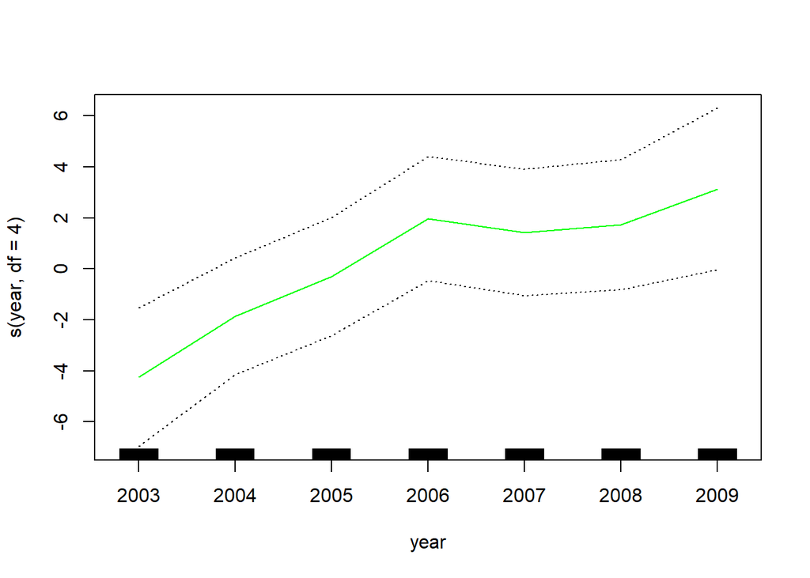

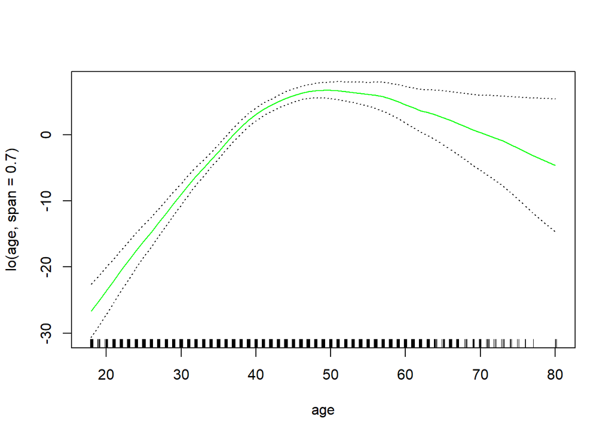

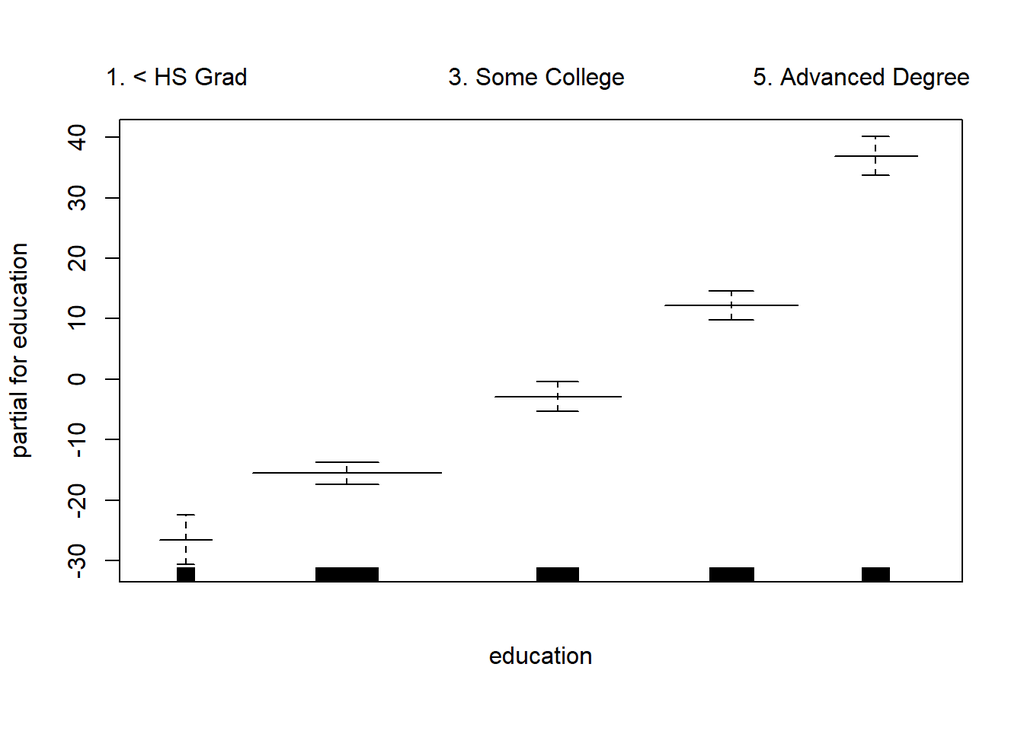

```r
plot.Gam(gam.lo, se=TRUE, col="green")
```

We can also use lo() to create interactions before calling Gam.

```r
gam.lo.i = gam(wage~lo(year,age,span=0.5) + education, data=Wage)
library(akima)
```

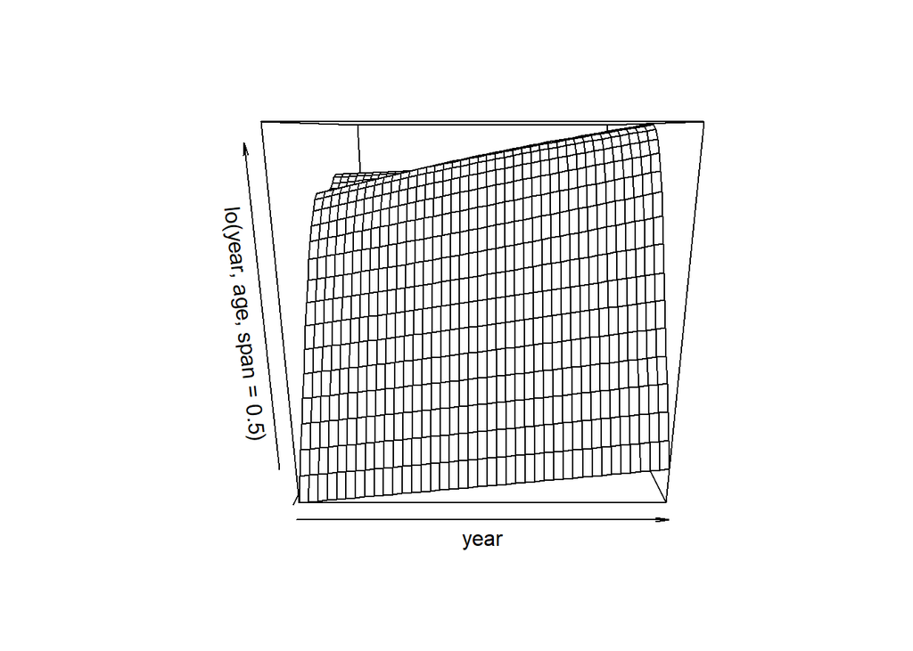

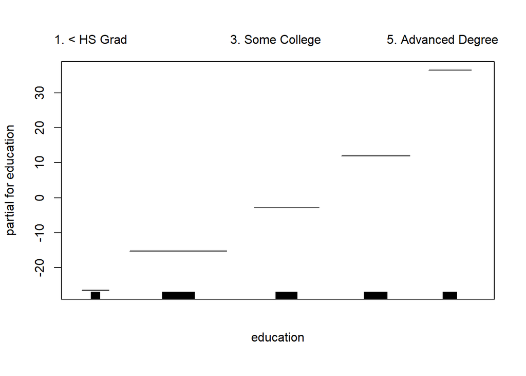

```r
plot(gam.lo.i)
```

```r
gam.lr = gam(I(wage>250)~year + s(age,df=5)+education, family = binomial, data=Wage)
```

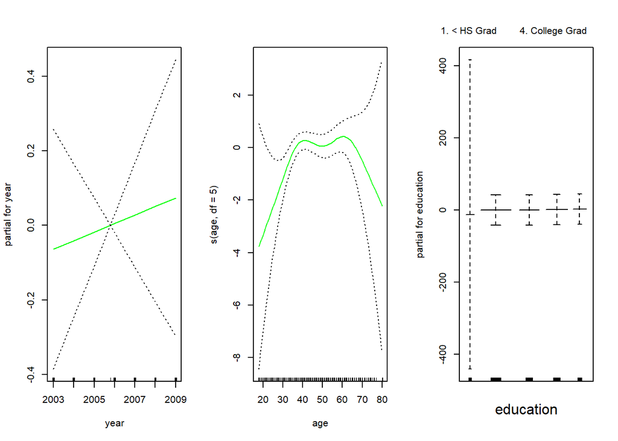

```r
par(mfrow=c(1,3))
plot(gam.lr,se=T,col="green")
```